# Random Forest and One-Class SVM for Email Spam Classifier

In this project, our task is to build a spam classifier using the UCR email spam dataset https://archive.ics.uci.edu/ml/datasets/Spambase came from the postmaster and individuals who had filed spam. The collection of non-spam emails came from filed work and personal emails, and hence the word "george" and the area code "650" are indicators of non-spam. These are useful when constructing a personalized spam filter.

We begin by training a CART classifier on the training data then evaluating the model against the test data. Given the type of classifier we can also plot the resulting decision tree to get a better understand of what exactly our model is doing behind the scenes. Of note I chose to split the test and train data the same way as in the following two questions so that their performance rates can be more accurately compared.

```
CART misclassification rate = 0.078
```

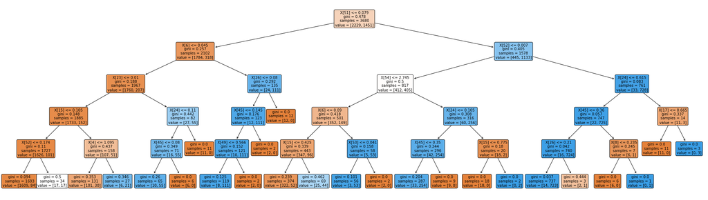

```python
import numpy as np
import scipy as sp
import pandas as pd
import sklearn
from sklearn.model_selection import train_test_split
from sklearn.tree import DecisionTreeClassifier
from sklearn.ensemble import RandomForestClassifier
from sklearn.svm import OneClassSVM
from sklearn import tree
import matplotlib.pyplot as plt


spam = pd.read_csv("spambase.data",sep=",",header=None)
data = np.array(spam.loc[:,spam.columns != 57].reset_index(drop=True).values)
labels = np.array(spam[57].reset_index(drop=True).values)
x_train, x_test, y_train, y_test = train_test_split(data,labels,test_size = .2,train_size=.8,random_state=10)
CART_1 = DecisionTreeClassifier(max_depth=5).fit(x_train,y_train)
pred = CART_1.predict(x_test)
cart_accuracy_rate = np.sum(y_test == pred)/y_test.shape[0]
cart_misclassification_rate = 1 - cart_accuracy_rate
print('CART misclassification rate = %s'%round(cart_misclassification_rate,3))
plt.figure(figsize=[35,10])
tree.plot_tree(CART_1,filled=True,rounded=True,fontsize=10)
plt.show()
```

Now let's also build a random forest model. Partition the data to use the first 80\% for training and the remaining 20\% for testing. We will compare and report the test error for your classification tree and random forest models on testing data. We will also plot the curve of test error (total mis-classification error rate) versus the number of trees for the random forest, and plot the test error for the CART model (which should be a constant with respect to the number of trees).

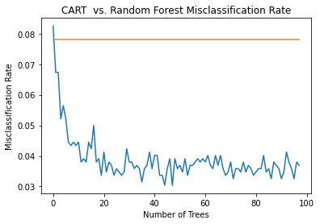

```python
forest_mis_class_rates = []
forest_accuracy = []
tree_index = np.arange(2,100)
cart_mis_class_ploter = np.repeat(cart_misclassification_rate,len(tree_index))
for i in tree_index:
    rf_clf = RandomForestClassifier(n_estimators=i).fit(x_train,y_train)
    rf_pred = rf_clf.predict(x_test)
    rf_acc = np.sum(y_test == rf_pred)/y_test.shape[0]
    rf_misclass = 1 - rf_acc
    forest_mis_class_rates.append(rf_misclass)
    forest_accuracy.append(rf_acc)

plt.plot(forest_mis_class_rates)
plt.plot(cart_mis_class_ploter)
plt.title('CART  vs. Random Forest Misclassification Rate')
plt.xlabel('Number of Trees')
plt.ylabel('Misclassification Rate')
plt.show()
```

As we can clearly see from the plot above, the CART model remains constant in its performance because varying the number of trees does not effect the model structure as it does with random forests. In the case of CART the primary determinate of the tree structure is instead the max depth parameter. In regard to the random forest approach we can see that initially we had a slightly superior performance from the CART model. However, this performance gap quickly narrowed as we increased the number of trees allowed within the random forest classifier. At around 20 trees we see the mis-classification rate start to stabilize and notice that after 20 we see minimal performance gain and lower variance among mis-calssification rates going forward. Although random forests succeeds in performance with a reasonable number of trees, the CART model still performs very well in general, and offers the possibility of better interpretability and less complexity than the random forest model equivalent.

Now we will try a one-class SVM approach for spam filtering. We will partition the data to use the first 80% for training and the remaining 20% for testing. Extract all non-spam emails from the training block (80% of data you have selected) to build the one-class kernel SVM using RBF kernel (you can turn the kernel bandwidth to achieve good performance). Then we will apply it on the 20% of data reserved for testing (thus this is a novelty detection situation), and report the total mis-classification error rate on these testing data.

Below, we can fit a one-class svm model on only the spam-free emails within our data-set. This will allow us to isolate what regular emails look like through the trained model perspective. Then, we can use this understating of what regular emails look like to identify outliers within the test data which would correspond to outliers according to our SVM one-class model. These outliers can be interpreted as the SVM's spam classifications. The model is implemented below:

```python
## Extract all non-spam emails form training data
x_train_spam_free = x_train[np.where(y_train == 0)]
x_train_spammed = x_train[np.where(y_train == 1)]
SVM_clf = OneClassSVM(kernel='rbf',gamma='auto', nu=.075).fit(x_train_spam_free)
SVM_predictions = SVM_clf.predict(x_test)
SVM_predictions = np.where(SVM_predictions == -1,1,0)
SVM_Accuracy = np.sum(y_test == SVM_predictions) / y_test.shape
print('One-Class SVM Test Accuracy = %s'%round(SVM_Accuracy[0],2))
```

```
One-Class SVM Test Accuracy = 0.71
```

As we can see the one-class SVM did not perform as well as our earlier two classifiers. However, considering a strictly unsupervised approach this was really a better application of outlier detection than classification. Thus in this context I find the one-class SVM to have performed rather well given its structure.